# Drug Arrests

Jeff Allen

10/14/2014

# Drug-Related Arrests in Lake County, CA

We’ve already downloaded the data (via `dataCollection.Rmd`) in the `data/` dir, so we’ll load it in and take a look.

```r
library(lubridate)

arrests <- readRDS("data/arrests.Rds")
load("data/bookings.Rda")
# Produces `bookings` and `charges` objects.
```

Now we can start identifying the charges that were drug-related.

```r
off <- sapply(charges, "[[", "Offense")
off <- sort(table(off), decreasing=TRUE)

head(off)
```

```
## off
##     BENCH WARRANT ARREST-M      PROBATION VIOLATION-M
##                       2004                       1257
##  POSS CONTROLLED SUBSTANCE DISORDERLY CONDUCT:ALCOHOL
##                        923                        909
##    POSS CONTRL SUBS PARAPH BATT:SPOUSE/EX SPOUSE/DATE
##                        869                        867
```

```r
tail(off)
```

```
## off
## WPN/TEAR GAS OFFENSE:PRISON/JAIL                             WRIT
##                                1                                1
##                           WRIT F            WRIT - NOT IN CUSTODY
##                                1                                1
##            WRIT OF HABEAS CORPUS             YOLO COUNTY DETAINER
##                                1                                1
```

In total we have 1011 offenses which is far more than I want to look through manually. We’ll filter down to those offenses that have 10 or more occurrences.

```r
# Subset to those offenses for which we have 10 or more records.
freqOff <- off[off>=10]
length(freqOff)
```

```
## [1] 170
```

```r
freqOff
```

```
## off
##           BENCH WARRANT ARREST-M            PROBATION VIOLATION-M
##                             2004                             1257
##        POSS CONTROLLED SUBSTANCE       DISORDERLY CONDUCT:ALCOHOL
##                              923                              909
##          POSS CONTRL SUBS PARAPH       BATT:SPOUSE/EX SPOUSE/DATE
##                              869                              867
##                             USE/  OUTSIDE AGENCY WARRANT ARREST-M
##                              857                              773
##                DUI ALCOHOL/DRUGS           BENCH WARRANT ARREST-F
##                              725                              674
## VIOLATE CT ORD PREVENT DOMES VIO                     COURT COMMIT
##                              632                              620
##  OBS/RESIST PUB/PEACE OFFCR/EMER  DIS COND:ALCOH RELEASED 849(B)2
##                              596                              558
##            PROBATION VIOLATION-F               PAROLE VIOLATION-F
##                              506                              496
##                           COMMIT INFLICT CORPORAL INJ ON SPOUSE/C
##                              446                              445
##         DUI ALCOHOL/0.08 PERCENT       POSSESS MARIJUANA FOR SALE
##                              391                              384
##  OUTSIDE AGENCY WARRANT ARREST-F       PLANT/CULTIVATE MJ/HASHISH
##                              379                              299
##           DRV WHILE LIC SUSP/REV            POSS NARC CONTRL SUBS
##                              285                              255
##        POSS CONTRL SUBS FOR SALE                     COURT REMAND
##                              230                              228
##                BATTERY ON PERSON                TRANS CONTRL SUBS
##                              218                              208
##                           REMAND                DRIVE W/O LICENSE
##                              188                              185
##    RCV/ETC KNOWN STOLEN PROPERTY                      IMMIGRATION
##                              184                              181
##            BURGLARY:FIRST DEGREE   THREATEN CRIME W/INT TERRORIZE
##                              172                              164
## DRV WHILE LIC SUSP/REV FOR DUI:S FORCE/ADW NOT FIREARM:GBI LIKELY
##                              158                              156
##             SELL/FURN MJ/HASHISH          CONSPIRACY:COMMIT CRIME
##                              134                              132
##    POSSESS CONCENTRATED CANNABIS       FALSE ID SPEC PEACE OFFCRS
```

[output cut: 116 more lines]

```
##                               10                               10
## DRV WHILE LIC SUSP/REV FOR RECKL ENTER/ETC NONCOMMERCIAL DWELLING
##                               10                               10
##                      EXH FIREARM                          FORGERY
##                               10                               10
## FORGERY:FALSE CHECKS/RECORDS/CER HABIT TRAFFIC OFFNDR:DRV:LIC SUS
##                               10                               10
## HIT & RUN RESULTING IN DEATH/INJ  Possession of an assault weapon
##                               10                               10
##                        PRCS HOLD           RAPE BY FORCE/FEAR/ETC
##                               10                               10
##                  REMANDED ON VOP          REMAND ON PREVIOUS BAIL
##                               10                               10
##                   RIDING BICYCLE              TAMPER WITH VEHICLE
##                               10                               10
```

```r
drugOff <- data.frame(off=names(freqOff), n=as.integer(freqOff), drug=rep(0, length(freqOff)))
```

I’m going to manually curate these to flag those that (to my knowledge) are drug-related.

```r
probablyDrugs <- c(3,5,22,24,28,37,57,61,79,88,96,126,140)
defDealing <- c(20,25,39,62,78,97,135)

drugOff$drug[probablyDrugs] <- 0.5
drugOff$drug[defDealing] <- 1
```

The offenses I said might be drug related are:

```r
probDrugChr <- as.character(drugOff$off[probablyDrugs])
probDrugChr
```

```
##  [1] "POSS CONTROLLED SUBSTANCE"        "POSS CONTRL SUBS PARAPH"
##  [3] "PLANT/CULTIVATE MJ/HASHISH"       "POSS NARC CONTRL SUBS"
##  [5] "TRANS CONTRL SUBS"                "SELL/FURN MJ/HASHISH"
##  [7] "POSS CONTRL SUBS WITHOUT A PRES"  "POSS HYPODERMIC NEEDLE/SYRINGE"
##  [9] "BRING CONTRL SUBS INTO PRISON/JA" "MAN CONTRL SUBS"
## [11] "POSS MJ 28.5 GRAMS/LESS"          "BRING ALC/DRGS INTO PRISON/JAIL"
## [13] "POSS CONTRL SUBS WHILE ARMED W/L"
```

The ones I think are definitely related to selling drugs are:

```r
defDealingChr <- as.character(drugOff$off[defDealing])
defDealingChr
```

```
## [1] "POSSESS MARIJUANA FOR SALE"       "POSS CONTRL SUBS FOR SALE"
## [3] "POSSESS CONCENTRATED CANNABIS"    "POSS MJ > 28.5 GRAMS"
## [5] "TRANS/SELL NARC/CONTRL SUBS"      "POSS/PURCHASE FOR SALE NARC/CONT"
## [7] "ARMED WHILE COMMITNG DRUG OFFENS"
```

Now we need to identify the dates on which these offenses were occurring. We’ll first annotate each of the charges with their “drug score” so we can summarize the score for each booking. We’ll just sum up this artificial score we created above to compute the drug “score” for that day across all bookings.

```r
# Create a data.frame for easier interaction
charge <- do.call(rbind.data.frame, charges)
charge$DrugScore <- 0
charge$DrugScore[charge$Offense %in% probDrugChr] <- 0.5
charge$DrugScore[charge$Offense %in% defDealingChr] <- 1

# Multiply by the number of counts
charge$DrugScore <- charge$DrugScore * as.integer(as.character(charge$Count))

bookingScores <- aggregate(charge$DrugScore, list(Booking=charge$BookingID), function(ds){sum(ds)})
```

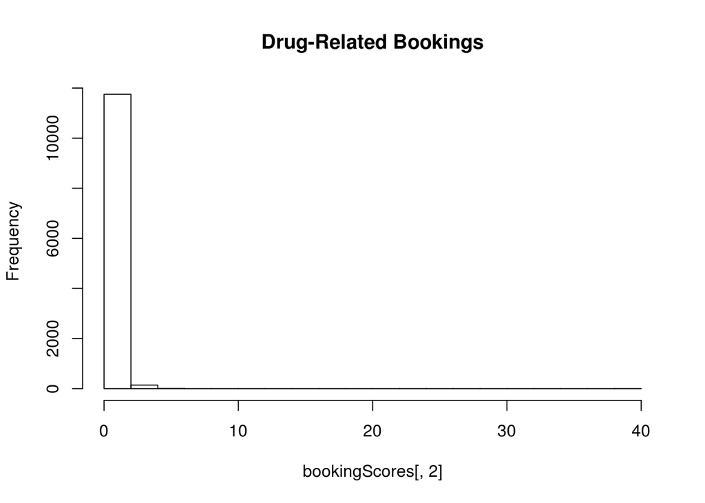

```r
hist(bookingScores[,2], main="Drug-Related Bookings")
```

Now that we have the scores for bookings, we can summarize the drug scores by date.

```r
library(lubridate)
arrests$DrugScore <- bookingScores[match(arrests$`Booking#`, bookingScores$Booking),2]
```

So we can now see, for all arrests in this time period, what were the drug scores?

```r
summary(arrests$DrugScore)
```

```
##    Min. 1st Qu.  Median    Mean 3rd Qu.    Max.    NA's
##     0.0     0.0     0.0     0.2     0.0    40.0     563
```

```r
table(arrests$DrugScore)
```

```
##
##    0  0.5    1  1.5    2  2.5    3  3.5    4  4.5    5   40
## 9837  801  548  435  133   82   31   20    7    3    1    1
```

So there are 563 arrests which don’t have a drug score, presumably because there were no charges or we weren’t able to fetch them from the website for some reason.

The next decision we’ll need to make is whether or not to cap these scores. I’m inclined to say that a single arrest for a Drug Score of 40 (???) doesn’t imply that there was 40x more drug activity on the day of that charge than on another day with a Drug Score of 1 – presumably it was just one big bust. So it probably makes sense for us to cap these scores at some value. I’m going to pick a max of 3.

I’m afraid the 40 entry is actually a bug anyways… I don’t see that many charges on that booking online. Oops.

```r
arrests$DrugScore[arrests$DrugScore > 3] <- 3
```

Now we can summarize by day:

```r
actByDay <- aggregate(arrests$DrugScore, list(Date=floor_date(as.POSIXct(arrests$`Time Booked`), "day")), sum)
summary(actByDay$x)
```

```
##    Min. 1st Qu.  Median    Mean 3rd Qu.    Max.    NA's
##    0.00    0.50    1.50    2.13    3.00   19.50      73
```

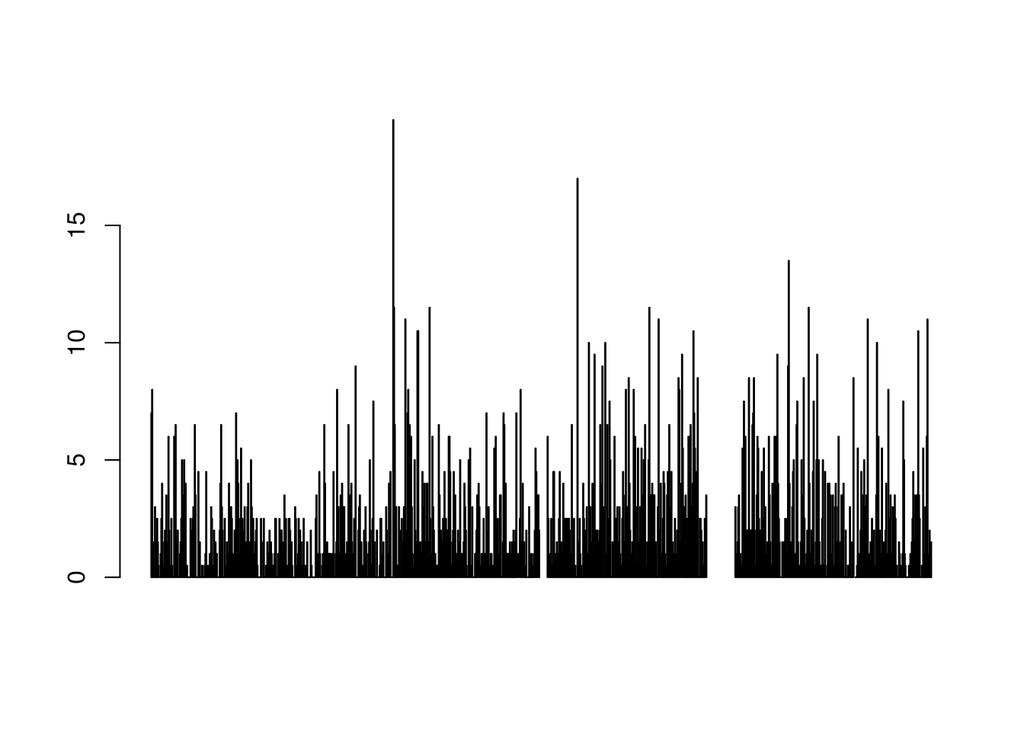

```r
barplot(actByDay$x)
```

This missing chunk looks suspicious…

```r
which(is.na(actByDay$x))
```

```
##  [1]   12  213  239  287  351  429  518  547  548  549  550  551  552  553
## [15]  554  555  556  557  564  716  745  782  783  784  785  786  787  788
## [29]  789  790  791  792  793  794  795  796  797  798  799  800  801  802
## [43]  803  804  805  806  807  808  809  810  811  812  813  814  815  816
## [57]  817  818  819  820  821  886  989  990  996 1035 1044 1051 1054 1065
## [71] 1078 1083 1093
```

Yeah, it looks like most missing days are contiguous around that block. So it’s possible that their server was down for a few seconds while I was querying, or the bookings for those days didn’t make it into the database, or something else strange.

## Correlate with Weather

```r
weather <- readRDS("weather.Rds")
weather <- weather[2:length(weather)]

wd <- data.frame(date=ymd(names(weather)), precip=as.numeric(sapply(weather, "[[", "precipi")))
```

I think there are packages that could do a rolling mean/sum, but we’ll just roll our own since it’s only a thousand elements.

```r
names(actByDay)[2] <- "Activity"

computePrecipWindow <- function(actByDay, wd, windowSize=3){
  rollPrecip <- wd
  for (i in nrow(wd):windowSize){
    rollPrecip[i,2] <- sum(rollPrecip[(i-windowSize+1):i,2], na.rm = FALSE)
  }

  # Trim first two rows off, for which we don't have data.
  rollPrecip <- rollPrecip[-windowSize+1:-1,]

  start <- max(min(actByDay$Date), min(rollPrecip$date))
  end <- min(max(actByDay$Date), max(rollPrecip$date))

  # Align dates
  actByDay <- actByDay[actByDay$Date <= end & actByDay$Date >= start,]
  rollPrecip <- rollPrecip[rollPrecip$date <= end & rollPrecip$date >= start,]
  wd <- wd[wd$date <= end & wd$date >= start,]
  actByDay$RollPrecip <- rollPrecip$precip

  actByDay$Precip <- wd$precip

  actByDay
}

act <- computePrecipWindow(actByDay, wd, 3)
head(act)
```

```
##         Date Activity RollPrecip Precip
## 1 2011-10-14      7.0          0      0
## 2 2011-10-15      8.0          0      0
## 3 2011-10-16      1.5          0      0
## 4 2011-10-17      0.5         NA     NA
## 5 2011-10-18      0.5         NA      0
## 6 2011-10-19      3.0         NA      0
```

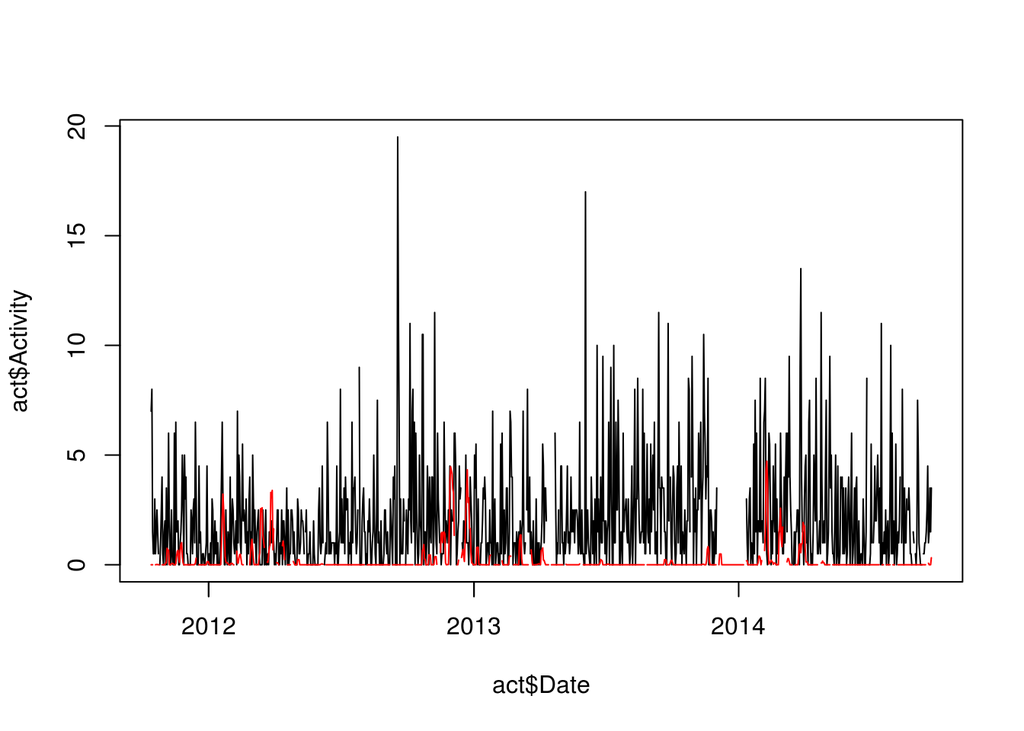

```r
plot(act$Date, act$Activity, type="l")
lines(act$Date, act$RollPrecip, col=2)
```

```r
cor(act$Activity, act$Precip, use="complete.obs")
```

```
## [1] 0.0045
```

```r
mod <- lm(act$Activity ~ act$Precip + act$RollPrecip)
mod
```

```
##
## Call:
## lm(formula = act$Activity ~ act$Precip + act$RollPrecip)
##
## Coefficients:
##    (Intercept)      act$Precip  act$RollPrecip
##         2.1295          0.0776         -0.0448
```

I wonder if the effect changes much as you change the number of days in the rolling window. Shiny to the rescue!

```r
saveRDS(actByDay, "abd.Rds")
saveRDS(wd, "wd.Rds")
```